# Getting TESS and *Kepler* light curves with **lightkurve**

## TESS in a nutshell:

- NASA mission launched in 2018 for continuous high-precision photometric observations
- Field-of-view of **96 deg x 24 deg** (4 cameras)
- Starring observations of 27 days for each FOV (aka **Sector**)
- The cadence of the observations is 2s but only 20s, 120s, 200s, and/or 1800s stamps are available. (**2-min** is the typical)
- 13 sectors constitute a year Cycle

[figure not shown]

- Since its launch, TESS has covered most of the sky.
- The ecliptic has been started to be covered recently
- A total of **97 sectors** have been completed so far in its **7 years mission** (Sector 98 started three days ago)

[figure not shown]

## TESS light curves

There are several pipelines that have extracted the TESS lightcurves. The main ones are:

## TESS/Kepler light curves using **lightkurve**

### Checking the TESS imagettes (aka **Target Pixel File**)

```python
import lightkurve as lk
```

```python
search_result = lk.search_targetpixelfile('WASP-10',mission='TESS',author='TESS-SPOC')
search_result
```

SearchResult containing 1 data products.

| # | mission | year | author | exptime s | target_name | distance arcsec |
| --- | --- | --- | --- | --- | --- | --- |
| 0 | TESS Sector 56 | 2022 | [TESS-SPOC](https://archive.stsci.edu/hlsp/tess-spoc) | 200 | 431701493 | 0.0 |

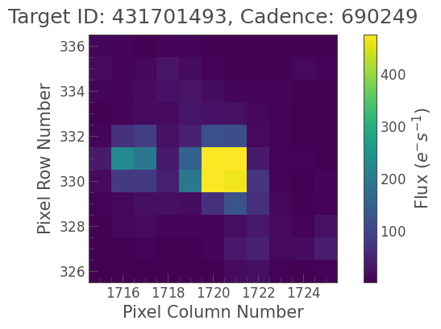

```python
tpf = search_result.download()
tpf.plot()
```

**BONUS TRACK**: Using `tpfplotter` (by J. Lillo-Box, https://github.com/jlillo/tpfplotter) you can make paper-ready figures of this to check for possible contaminants using Gaia DR3:

`> python tpfplotter.py 431701493`

[figure not shown]

### Searching for light curves and downloading

```python
# Imports and functions
%matplotlib inline
import lightkurve as lk
import numpy as np
```

```python
# Light curve search -- several sectors
search_result_0 = lk.search_lightcurve('Kepler-91',mission='TESS', author='SPOC',exptime=120) # Additional options: exptime=120, author='TESS-SPOC'
search_result_0
```

[output not shown]

```python
# Light curve search -- one sector
search_result = lk.search_lightcurve('WASP-10',mission='TESS',author='TESS-SPOC') # Additional options: exptime=120
search_result
```

SearchResult containing 1 data products.

| # | mission | year | author | exptime s | target_name | distance arcsec |
| --- | --- | --- | --- | --- | --- | --- |
| 0 | TESS Sector 56 | 2022 | [TESS-SPOC](https://archive.stsci.edu/hlsp/tess-spoc) | 200 | 431701493 | 0.0 |

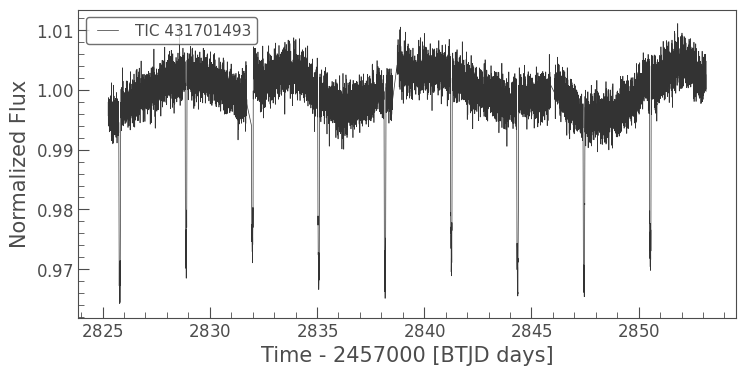

```python
# Get data and stitch (when more than one sector are available)
lc = search_result.download_all()
lcs = lc.stitch().remove_nans()
lcs.plot()
```

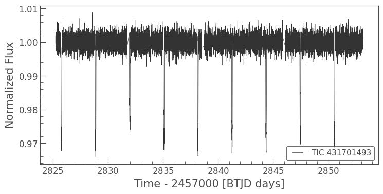

```python
# Flatten the lightcurve
lcsf = lc.stitch().remove_nans().flatten(window_length=200)
lcsf.plot()
```

### Identifying periodicities

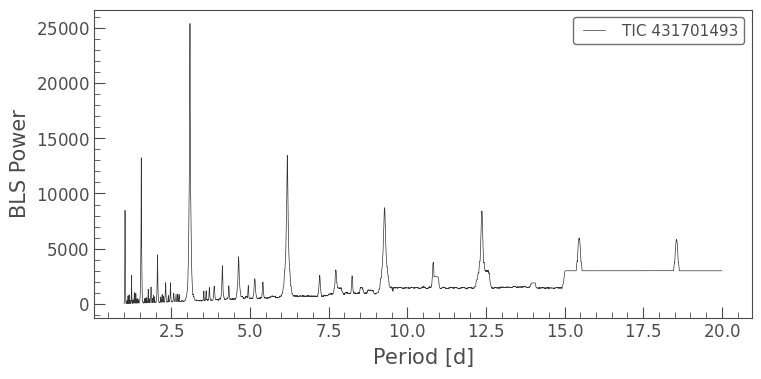

```python
# Create array of periods to search
periods = np.linspace(1, 20, 10000)
# Create a BLSPeriodogram
bls = lcsf.to_periodogram(method='bls', period=periods, frequency_factor=500);
bls.plot();
```

```python
# Find the peak of the periodogram:
planet_b_period = bls.period_at_max_power
planet_b_t0     = bls.transit_time_at_max_power
planet_b_dur    = bls.duration_at_max_power

# Check the value for period
planet_b_period
```

$3.0940094 \; \mathrm{d}$

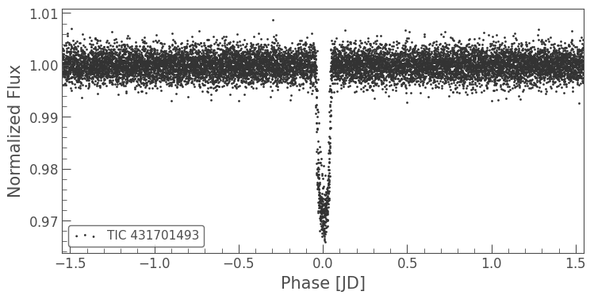

```python
# Plot the phase-folded lightcurve on the peak periodicity:
ax = lcsf.fold(period=planet_b_period, epoch_time=planet_b_t0).scatter()
ax.set_xlim(-planet_b_period.value/2, planet_b_period.value/2);
```

```python
# Accessing time, flux, eflux:
time  = lcsf.time
flux  = lcsf.flux
eflux = lcsf.flux_err
```

### Identifying stellar rotation periods:

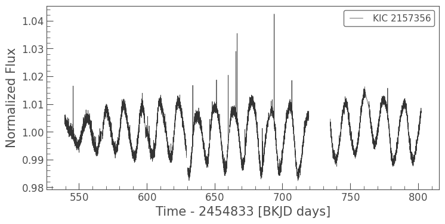

```python
# Search light curve
search_result = lk.search_lightcurve('KIC 2157356', author='Kepler', quarter=(6, 7, 8))

# Download and stitch the data together
lc = search_result.download_all().stitch()

# Plot the resulting light curve
lc.plot();
```

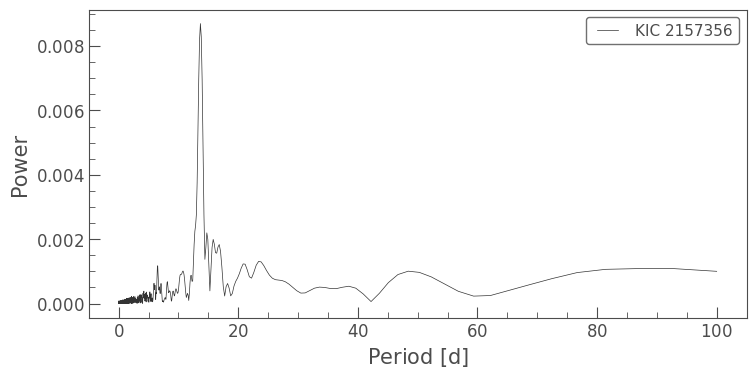

```python
# Lomb-Scargle periodogram
pg = lc.to_periodogram(maximum_period=100)
pg.plot(view='period');
```

```python
Prot = pg.period_at_max_power
print("Your Prot is ",Prot)
```

```
Your Prot is  13.670865233376269 d
```

### River diagrams

```python
lc = lk.search_lightcurve('KIC 6185476', author='Kepler', cadence='long').download_all().stitch().flatten(window_length=21)
```

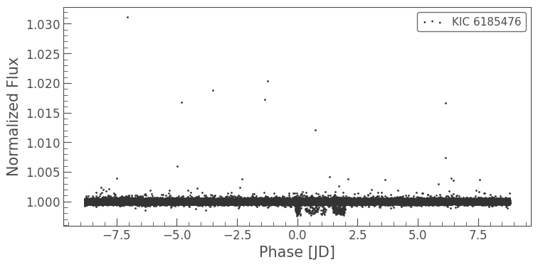

```python
# Period (p) and and reference transit time (t0) are taken from the NASA Exoplanet Archive
p, t0 = 17.660114, 136.57258
folded_lc = lc.fold(period=p, epoch_time=t0)

# If we now plot the phase-fodled lightcurve, the transit does not clearly show up...
folded_lc.scatter();
```

This is because the planet is dynamically interacting with other bodies in the system and the transit is **not strictly periodic**.

This can be beautifully respresented in a river-plot diagram:

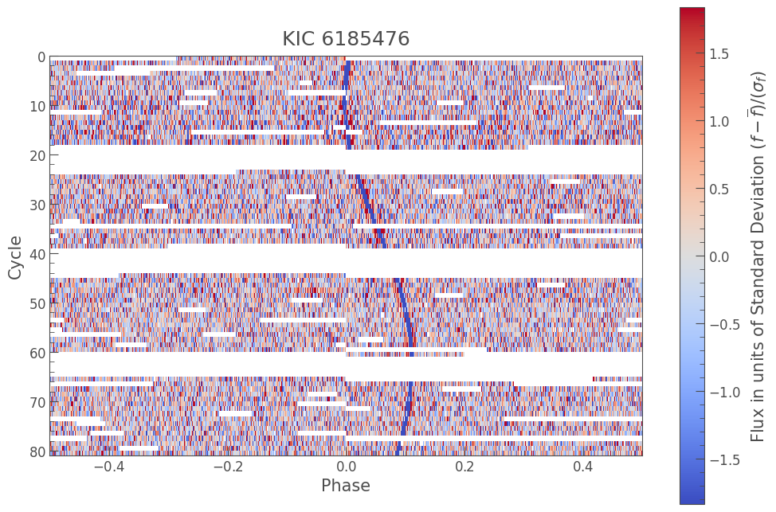

```python
folded_lc.plot_river(bin_points=1, method='sigma');
```

### Citing lightkurve

```python
# Citing lighkurve...
lk.show_citation_instructions()
```

When using Lightkurve, we kindly request that you cite the following packages:

- [lightkurve](https://docs.lightkurve.org)

- [astropy](https://astropy.org)

- [astroquery](https://astroquery.readthedocs.io) — if you are using *search_lightcurve()* or *search_targetpixelfile()*.

- [tesscut](https://mast.stsci.edu/tesscut/) — if you are using *search_tesscut()*.